# Estudo sobre a base Titanic

Leandro Duarte

06/12/2021

## Introdução e Resumo.

O objetivo primordial deste estudo é aplicar os conhecimentos aprendidos em Estatística Computacional com o professor Luís Machado (MECD), apresentando os passos e comandos utilizados no R. Além disso, foi ambicionado fazer uma Análise Descritiva (Uni e Multidimensional), Estimação (Pontual e Intervalar) e, por fim, apresentar alguns modelos para a previsão da variável resposta.

Para cumprir tais objetivos, foi escolhido trabalhar com a base de dados Titanic porque ela apresenta uma quantidade razoável de variáveis explicativas qualitativas (ordinais e nominais) e quantitativas (discretas e contínuas). Ademais, referida base é proveniente de um acidente histórico real que até hoje é relembrado pelas pessoas, às quais assistiram aos filmes e foram (ou desejaram ir) ao museu do Titanic, em Belfast.

Com efeito, o **RMS Titanic** foi um navio luxuoso construído para ser ‘inafundável’. Partiu dia 10 de abril de 1912 com 2224 pessoas (passageiros e tripulantes) e o acidente ocorreu dia 15 de abril daquele ano, acarretando provavelmente em **mais de 1500 mortes** (foi estimado que o total de mortes está entre 1490 e 1635) [(ver Wikipédia)](https://en.wikipedia.org/wiki/Titanic).

Considerando que a base que temos acesso possui informações sobre **1309** passageiros, ou seja, praticamente todos os existentes (2224 - 688 tripulantes = 1536), as medidas calculadas seriam populacionais e não amostrais, o que inviabilizaria fazer inferências ou construir modelos. Então, todo o exposto será uma abstração para focarmos nas técnicas computacionais e estatísticas.

Dito isto, consideramos que estamos interessados em determinar qual é a proporção de passageiros que sobreviveram ao acidente e também prever se um passageiro sobreviveu ao acidente, tendo posse de algumas informações sobre ele. Consideraremos que a variável resposta será **survived**, caracterizada por 1 se o passageiro sobreviveu ao acidente ou 0 em caso contrário. A **proporção de sobreviventes** estimada para a população foi de **0,382**.

Pela Análise da Descritiva, percebemos que a proporção de **mulheres** que sobreviveram ao acidente foi **maior** que a dos **homens** (**72,75%** contra **19,10%**). Também percebemos que as pessoas que viajaram na **primeira** classe tiveram uma proporção **maior** de sobreviventes (de **61,92%** contra **25,53%** dos que viajaram na **terceira** classe). Pessoas que embarcaram no porto **“C” (Cherbourg)** também possuíram uma proporção **maior** de sobreviventes (**55,56%** contra **33,56%** nos outros portos). Através da idade, percebemos que as **crianças e jovens** tiveram uma proporção **maior** de sobreviventes. Quanto à **fare**, vemos que os passageiros que pagaram **mais** nas passagens também tiveram uma proporção **maior** de sobreviventes. Pessoas que embarcaram **sozinhas** tiveram **menor** proporção de sobreviventes, sendo que recolhemos esta informação utilizando as variáveis **sibsp** e **parch**.

Também encontramos alguns problemas nas variáveis, tais como número considerável de valores faltantes na *age*, presença de valores extremos na variável **fare** e muitos valores concentrados no zero nas variáveis **sibsp** e **parch**.

No tocante à Inferência Estatística, obtivemos a estimativa pontual de **0,382** e construímos o intervalo **[0,356 ; 0,408]** com grau de confiança de 95% para a proporção de passageiros sobreviventes. Utilizando intervalos de confiança e Testes de Hipóteses (utilizando nível de significância de 5%), vimos quais diferenças encontradas na Análise Descritiva são significativas.

No capítulo referente à Modelagem, apresentamos modelos de Árvores de Decisão Simples, Regressão Logística e KNN, além de mostrarmos algumas técnicas de pré-processamento, construções de novas variáveis explicativas, combinações de modelos, critérios de seleção de modelos e também formas de tentar aumentar a acurácia na previsão da variável resposta através da “votação” de todos os modelos. Se optássemos por escolher o modelo que forneceu a maior acurácia total, escolheríamos o obtido pelo KNN (com k=15), o qual forneceu a acurácia total de **81,17%** para a base de validação.

## Análise Descritiva Univariada.

```
1. Dicionário de variáveis
```

- **survived**: Sobrevivência (ou não) dos passageiros. Possíveis valores: 0 (morreu) ou 1 (sobreviveu);
- **pclass**: Classe do Bilhete. Possíveis valores: 1(primeira), 2(segunda) ou 3 (terceira); `
- **sex**: Gênero do passageiro. Possíveis valores: female (feminino) ou male (masculino);
- **age**: Idade (em anos). Possíveis valores: para crianças menores de um ano, a idade pode assumir um valor contínuo (no intervalo ]0,1[). Para mais velhos que isso, usa-se o valores discretos {1,2,3…}. Quando tem o valor da forma xx.5 é porque a idade da pessoa foi estimada.
- **sibsp**: Número de irmãos e/ou esposos a bordo. Possíveis valores: {0,1,2,3…};
- **parch**: Número de pais e/ou filhos a bordo. Possíveis valores: {0,1,2,3…};
- **fare**: Valor da tarifa paga. Possíveis valores: ]0,+∞[;
- **embarked**: Porto de Embarque. Possíveis valores: C (Cherbourg), Q (Queenstown) ou S (Southampton);
- **death**: Morte (ou não) do passageiro. Possíveis valores: 0 (não morreu) ou 1(morreu). Esta variável será descartada porque foi obtida pela variável **survived**.

Observe o tipo das variáveis e depois os primeiros registros em forma tabular:

```r
df<-subset(df, select=-death)
str(df)
```

```
## 'data.frame':    1309 obs. of  8 variables:
##  $ pclass  : Factor w/ 3 levels "1","2","3": 1 1 1 1 1 1 1 1 1 1 ...
##  $ survived: Factor w/ 2 levels "0","1": 2 2 1 1 1 2 2 1 2 1 ...
##  $ sex     : Factor w/ 2 levels "female","male": 1 2 1 2 1 2 1 2 1 2 ...
##  $ age     : num  29 0.917 2 30 25 ...
##  $ sibsp   : int  0 1 1 1 1 0 1 0 2 0 ...
##  $ parch   : int  0 2 2 2 2 0 0 0 0 0 ...
##  $ fare    : num  211 152 152 152 152 ...
##  $ embarked: Factor w/ 4 levels "","C","Q","S": 4 4 4 4 4 4 4 4 4 2 ...
```

```r
head(df)
```

```
##   pclass survived    sex     age sibsp parch     fare embarked
## 1      1        1 female 29.0000     0     0 211.3375        S
## 2      1        1   male  0.9167     1     2 151.5500        S
## 3      1        0 female  2.0000     1     2 151.5500        S
## 4      1        0   male 30.0000     1     2 151.5500        S
## 5      1        0 female 25.0000     1     2 151.5500        S
## 6      1        1   male 48.0000     0     0  26.5500        S
```

Também vale observar a tabela resumo, pois ela apresenta as frequências das variáveis qualitativas, medidas descritivas das variáveis quantitativas e a quantidade de registros faltantes em cada atributo:

```r
summary(df)
```

```
##  pclass  survived     sex           age              sibsp
##  1:323   0:809    female:466   Min.   : 0.1667   Min.   :0.0000
##  2:277   1:500    male  :843   1st Qu.:21.0000   1st Qu.:0.0000
##  3:709                         Median :28.0000   Median :0.0000
##                                Mean   :29.8811   Mean   :0.4989
##                                3rd Qu.:39.0000   3rd Qu.:1.0000
##                                Max.   :80.0000   Max.   :8.0000
##                                NA's   :263
##      parch            fare         embarked
##  Min.   :0.000   Min.   :  0.000    :  2
##  1st Qu.:0.000   1st Qu.:  7.896   C:270
##  Median :0.000   Median : 14.454   Q:123
##  Mean   :0.385   Mean   : 33.295   S:914
##  3rd Qu.:0.000   3rd Qu.: 31.275
##  Max.   :9.000   Max.   :512.329
##                  NA's   :1
```

Quanto às informações faltantes, a única variável **alarmante** é a **age** (20,09% dos registros). Veremos, na seção 3.2, algumas formas de contornar este problema.

```
2. Variáveis Qualitativas

2.1 Variáveis Qualitativas Nominais
```

**Sex** (female ou male)

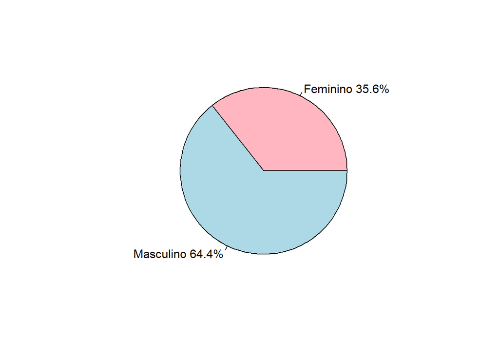

```r
label.pie<-c("Feminino","Masculino")
freq<-round(table(df$sex)/nrow(df)*100,2)
label.pie<-paste(label.pie,freq)
label.pie<-paste(label.pie,"%",sep="")
pie(x=table(df$sex), labels=label.pie, col = c("lightpink", "lightblue"))
```

Das 1309 observações, temos 466 mulheres (35,60%) e 843 homens (64,40%), ou seja, não temos valores faltantes e há predominância de homens na amostra. No gráfico a seguir, veremos se o gênero do passageiro ajudaria a explicar sua sobrevivência (ou não) ao acidente.

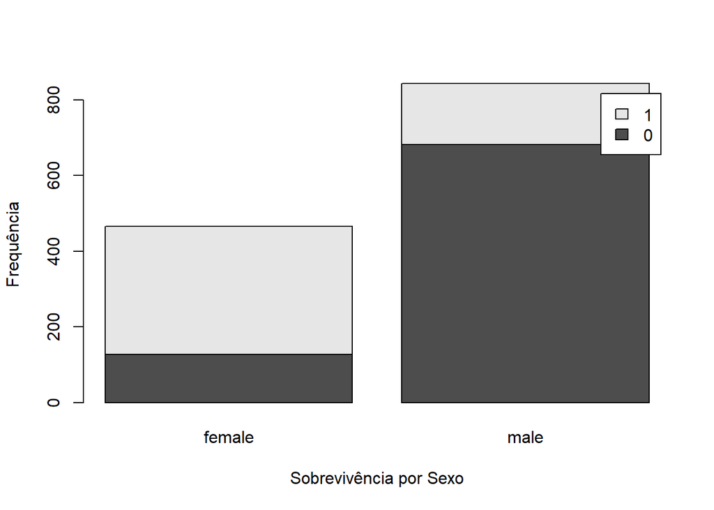

```r
barplot(table(df$survived,df$sex), xlab="Sobrevivência por Sexo", ylab="Frequência",
        legend.text = TRUE, beside=FALSE)
```

Pela apreciação desse gráfico, percebe-se que a **proporção** de sobreviventes das **mulheres** é **bem superior** a dos **homens** (**72,75%** contra **19,09%**), indicando assim que o gênero pode ajudar a explicar a sobrevivência de um passageiro.

**Embarked** (C - Cherbourg, Q - Queenstown ou S - Southampton)

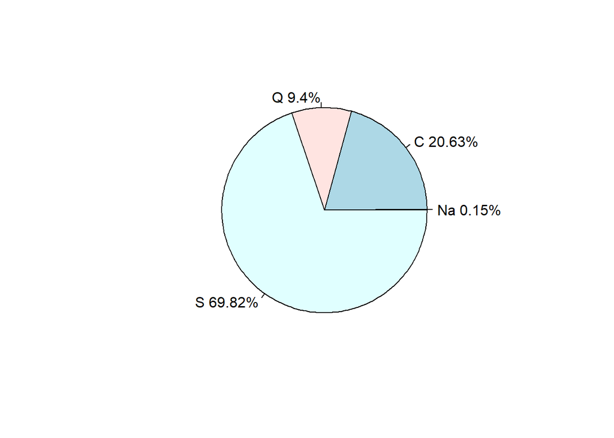

```r
label.pie<-c("Na", "C","Q", "S")
freq<-round(table(df$embarked)/nrow(df)*100,2)
label.pie<-paste(label.pie,freq)
label.pie<-paste(label.pie,"%",sep="")
pie(x=table(df$embarked), labels=label.pie)
```

Percebemos que o Porto de **S** (Southampton) é o **mais frequente** e que esta variável possui apenas 2 valores faltantes. Quanto ao comportamento desta variável em relação à resposta, temos:

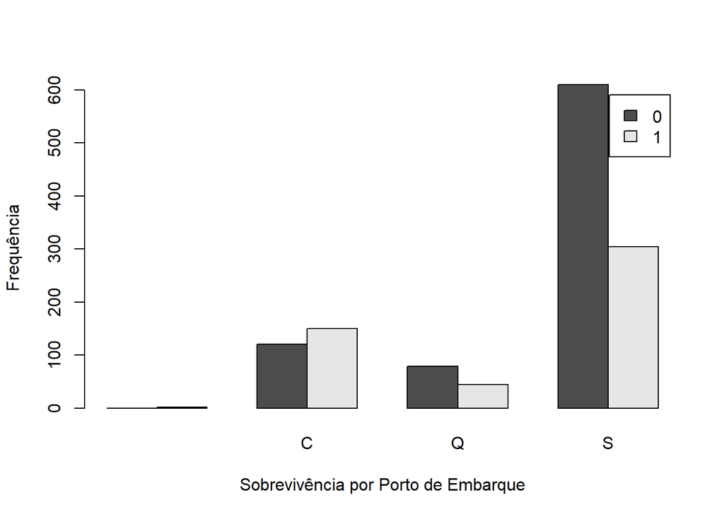

```r
barplot(table(df$survived,df$embarked), xlab="Sobrevivência por Porto de Embarque", ylab="Frequência",
        legend.text = TRUE, beside=TRUE)
```

Pela apreciação do gráfico, percebemos que a proporção de sobreviventes no porto C é **maior** que a proporção dos outros portos. Além disso, temos que a proporção de sobreviventes no porto Q está **próxima** da do S. Veremos no capítulo de Inferência Estatística se essas 3 categorias possuem diferenças significativas.

```
2.2 Variáveis Qualitativas Ordinais
```

**Pclass** (1, 2 ou 3)

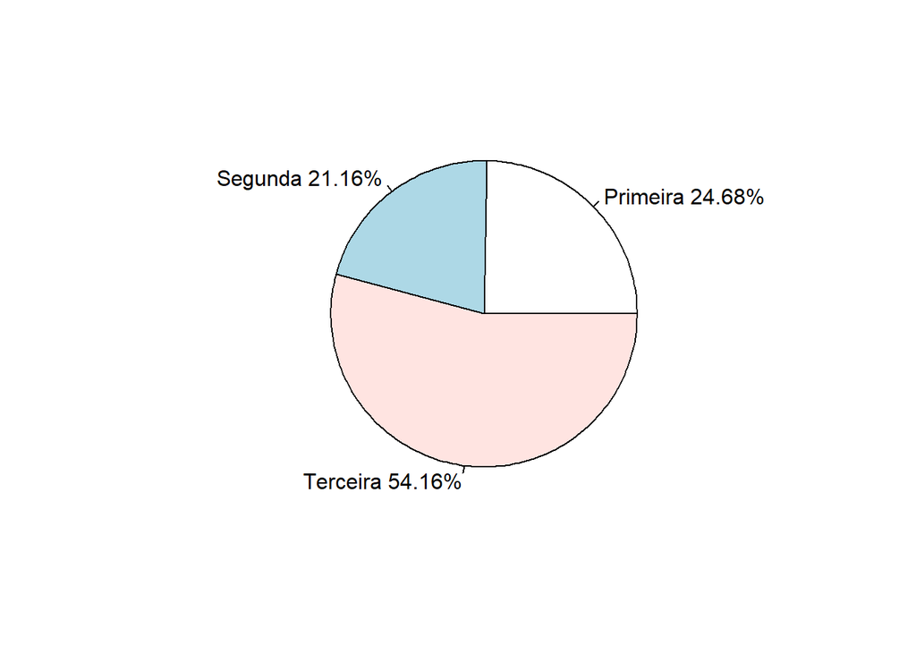

```r
label.pie<-c("Primeira","Segunda", "Terceira")
freq<-round(table(df$pclass)/nrow(df)*100,2)
label.pie<-paste(label.pie,freq)
label.pie<-paste(label.pie,"%",sep="")
pie(x=table(df$pclass), labels=label.pie)
```

Observando o gráfico acima, percebemos que a **Terceira** classe é a **mais frequente**. Quanto a proporção de sobreviventes, temos:

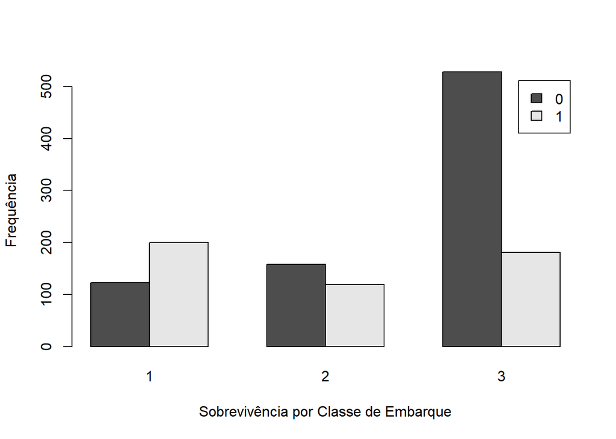

```r
barplot(table(df$survived,df$pclass), xlab="Sobrevivência por Classe de Embarque", ylab="Frequência",
        legend.text = TRUE, beside=TRUE)
```

Temos a sugestão de que quanto **pior** é a classe **menor** é a proporção de sobreviventes.

```
3. Variáveis Quantitativas

3.1 Variáveis Quantitativas Discretas
```

**Sibsp** (Número de irmãos e/ou esposos)

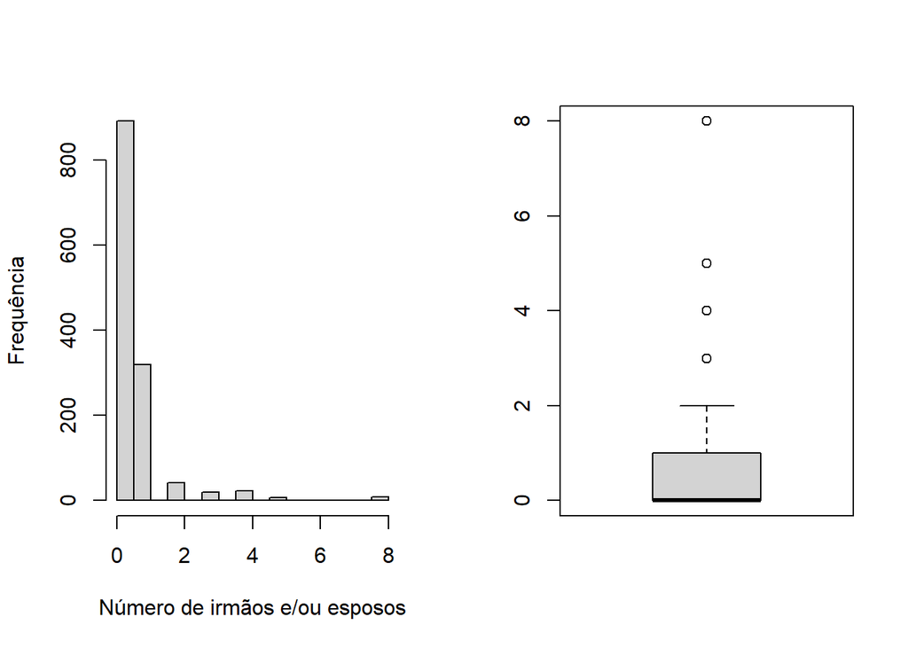

```r
layout(matrix(c(1,2),ncol=2))
hist(df$sibsp, freq = TRUE ,ylab = "Frequência", xlab="Número de irmãos e/ou esposos",main="")
boxplot(df$sibsp)
```

Pelos gráficos acima, percebe-se que a **maioria** dos passageiros embarcou **sozinha** ou com apenas um(a) irmã(o) (ou esposo(a)). De fato, **apenas 4,35%** dos passageiros possuía 3 ou mais irmãos. Levando isto em consideração, um gráfico de barras nos fornece uma visualização melhor. Nesse sentido, aprecie o seguinte gráfico:

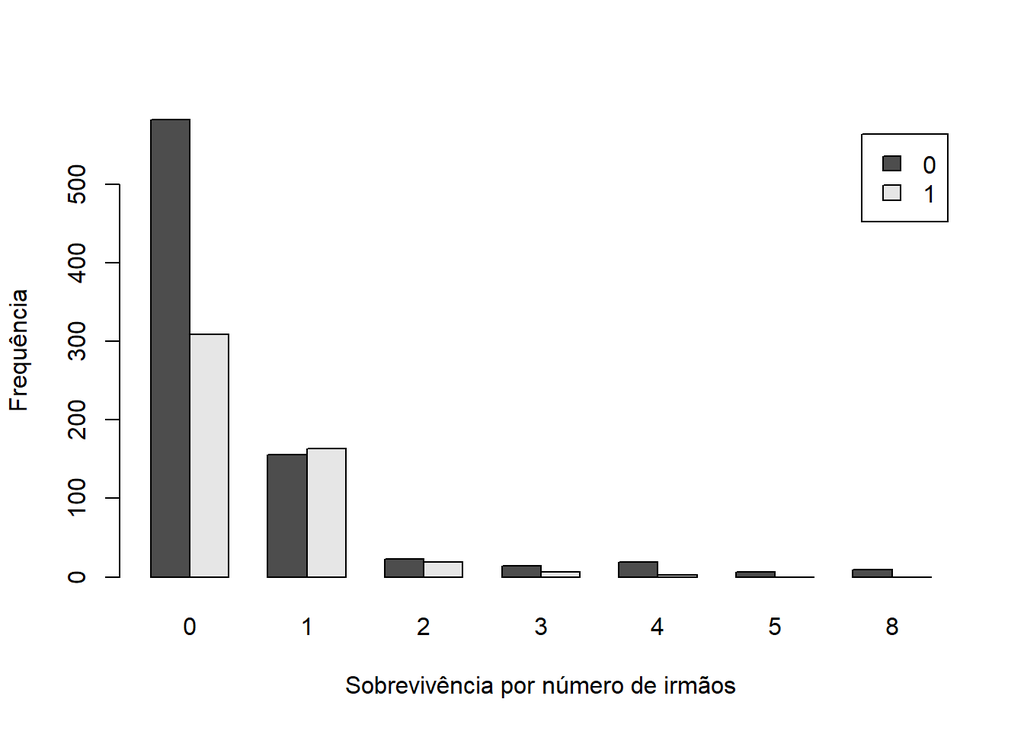

```r
barplot(table(df$survived,df$sibsp), xlab="Sobrevivência por número de irmãos", ylab="Frequência",
        legend.text = TRUE, beside=TRUE)
```

Vemos pelo gráfico que os passageiros que embarcaram com 1 ou 2 irmãos tiveram uma proporção **maior** de sobreviventes e os que possuíam 3 ou mais irmãos tiveram as **menores** proporções de sobreviventes.

**Parch** (Número de pais e/ou filhos a bordo)

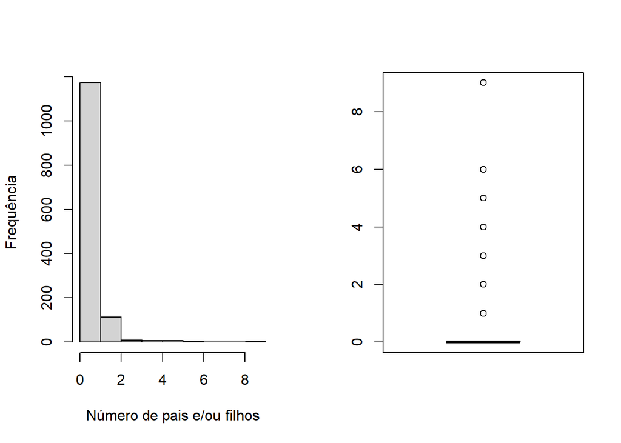

```r
layout(matrix(c(1,2),ncol=2))
hist(df$parch, freq = TRUE ,ylab = "Frequência", xlab="Número de pais e/ou filhos",main="")
boxplot(df$parch)
```

Assim como na **sibsp**, a **maioria** dos passageiros embarcou **sozinha** ou possuía apenas um ou dois filhos (ou pais). Utilizando o mesmo raciocínio da variável anterior, temos:

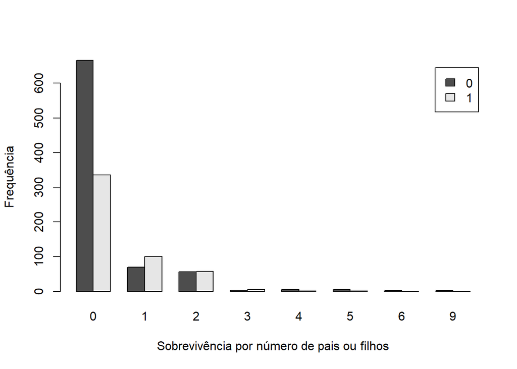

```r
barplot(table(df$survived,df$parch), xlab="Sobrevivência por número de pais ou filhos", ylab="Frequência",
        legend.text = TRUE, beside=TRUE)
```

Aqui parece que ter embarcado com filhos (ou pais) **aumentou** a proporção de sobreviventes, pese o fato de haver poucas observações com valores diferentes de 0.

```
3.2 Variáveis Quantitativas Contínuas
```

**Age**

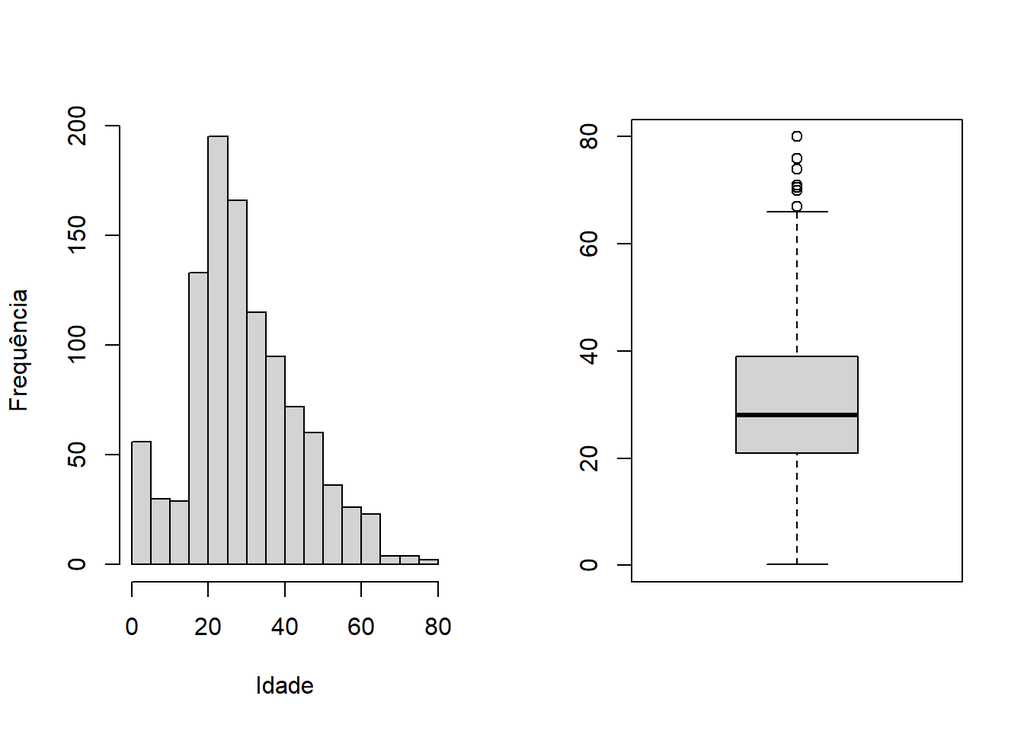

```r
layout(matrix(c(1,2),ncol=2))
hist(df$age, freq = TRUE ,ylab = "Frequência", xlab="Idade",main="")
boxplot(df$age)
```

Pela apreciação dos gráficos, percebe-se que as faixas ]20,25] e ]25,30] são as **mais frequentes**, com uma leve assimetria à direita. Para ilustramos nossa assertiva, observe a distribuição da amostra com a comparação de uma curva normal.

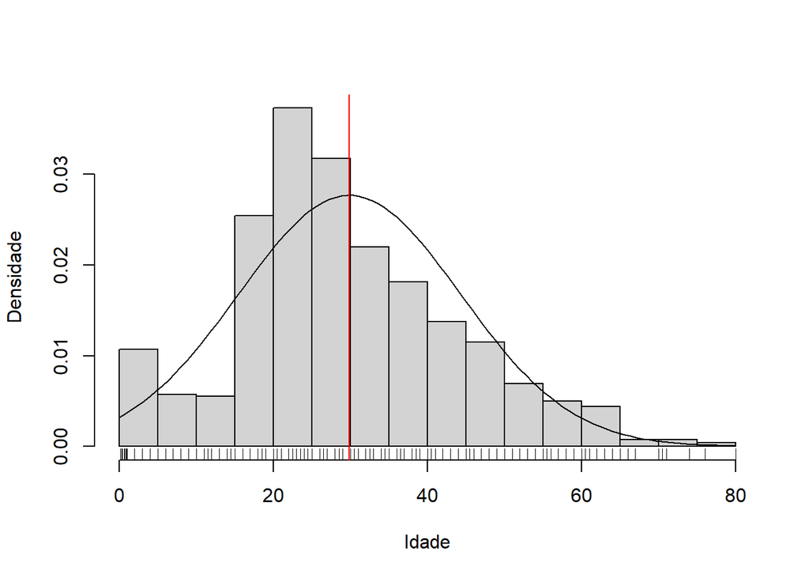

```r
hist(df$age, freq = FALSE ,ylab = "Densidade", xlab="Idade",main="")
curve(dnorm(x,mean = mean(df$age, na.rm = TRUE),sd=sd(df$age, na.rm = TRUE)),add=TRUE)
rug(df$age)
abline(v=mean(df$age, na.rm = TRUE),col="red")
```

O gráfico abaixo serve para compararmos as distribuições dos passageiros que sobreviveram e a dos que faleceram no acidente. Elas aparentam ser muito semelhantes.

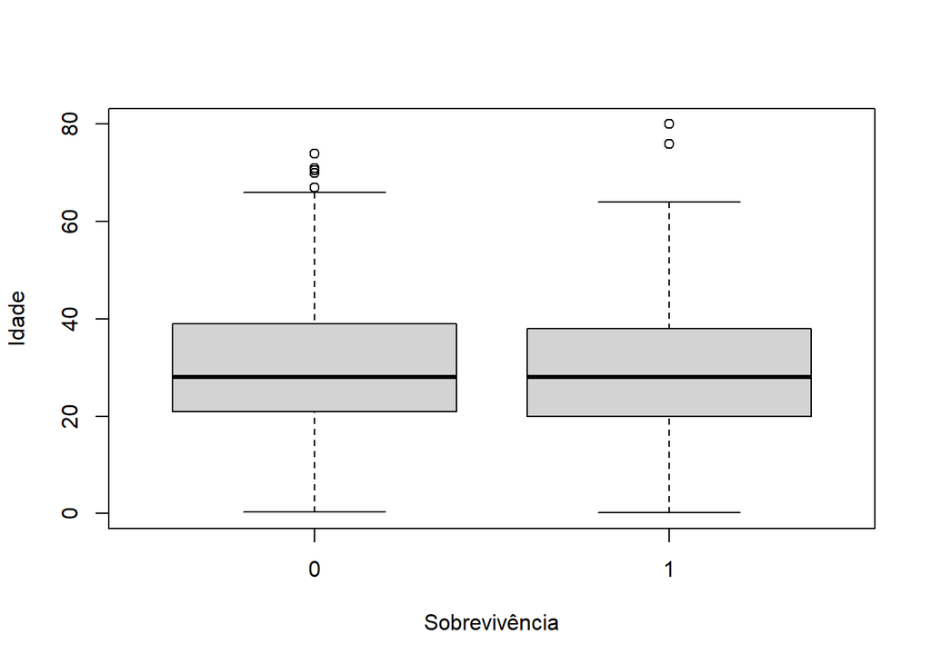

```r
boxplot(df$age~df$survived, ylab = "Idade", xlab="Sobrevivência",main="")
```

Porém, observando os respectivos histogramas, percebe-se que **crianças e adolescentes** tiveram uma proporção **maior** de sobreviventes.

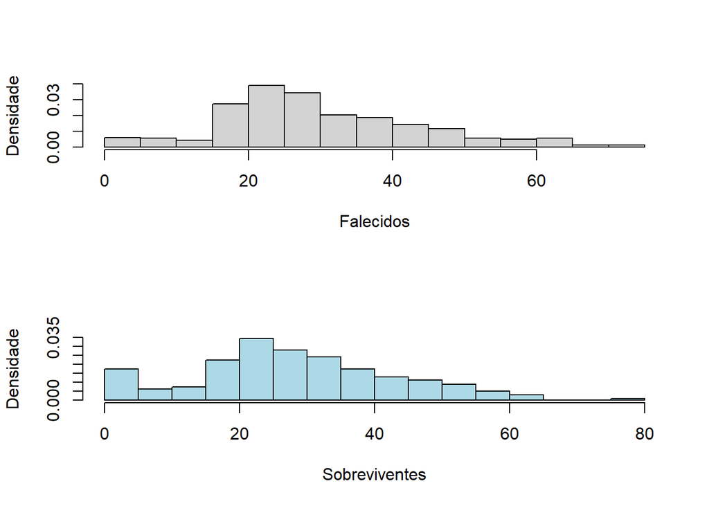

```r
mor<-df$age[df$survived==0]
viv<-df$age[df$survived==1]

layout(matrix(c(1,2),ncol=1))
hist(mor, freq = FALSE, breaks = 12, xlab = "Falecidos", ylab="Densidade", main="")
hist(viv, freq = FALSE, col = "lightblue", breaks = 12, xlab = "Sobreviventes",ylab="Densidade", main="")
```

Por fim, temos que esta variável apresenta **20.09%** de seus valores faltantes. Além disso, há a sugestão de que sua proporção de sobreviventes é **menor** quando comparada à dos adultos (**27,76%** contra **38,77%**).

Como algumas técnicas de modelagem não permitem a utilização de “missings”, costuma-se contornar esse problema com uma das seguintes formas:

1. removendo registros faltantes da base;
2. substituindo os valores faltantes por alguma medida de centralidade (mediana, média ou a moda amostrais);
3. excluindo a variável do modelo;

Entre essas opções, a segunda se afigura como mais razoável, pese o fato de suspeitarmos que não saber a idade pode representar também uma fonte de “informação”. Então usaremos a média amostral para substituir os valores faltantes e chamaremos essa “nova” variável de **age_2** e também trabalharemos considerando a idade como uma variável categórica denominada de **faixa_etaria**.

**Fare**

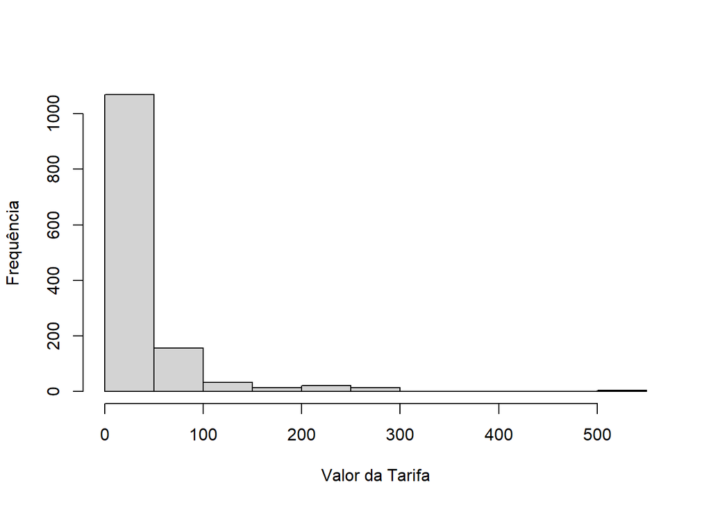

```r
hist(df$fare, ylab = "Frequência", xlab = "Valor da Tarifa", main="")
```

Percebemos que a variável **fare** possui valores mais concentrados à esquerda do gráfico e também apresenta alguns valores extremos que acabam por aumentar a amplitude de cada intervalo, dificultando nossa visualização. Antes de fazermos algum tipo de ajuste (aumentando o número de “bins”, agrupando alguns valores ou removendo os “outliers”), é de bom alvitre olharmos o comportamento desta variável em relação à resposta.

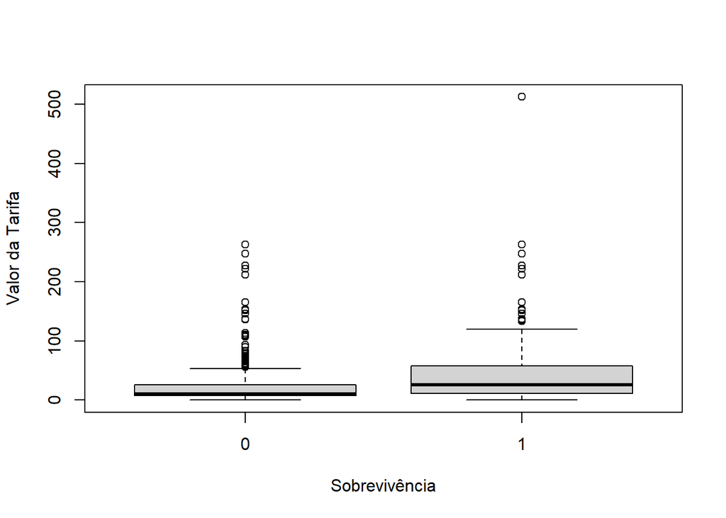

```r
boxplot(df$fare~df$survived, ylab = "Valor da Tarifa", xlab="Sobrevivência",main="")
```

Mesmo com os valores extremos distorcendo a escala, percebe-se que os que pagaram **tarifas mais altas** tiveram uma proporção **maior** de sobreviventes. Porém, será que este resultado não está melhor descrito pela variável **pclass**? Para respondermos esse e outros questionamentos, faremos uma Análise Descritiva Multivariada.

## Análise Descritiva Multivariada.

```
1. Embarked (Porto de Embarque) vs pclass (Classe da Viagem)
```

Nas seções anteriores, vimos que as pessoas que estavam na primeira classe e as que embarcaram no Porto C tiveram maiores proporções de sobreviventes. Será que há associação entre essas duas variáveis?

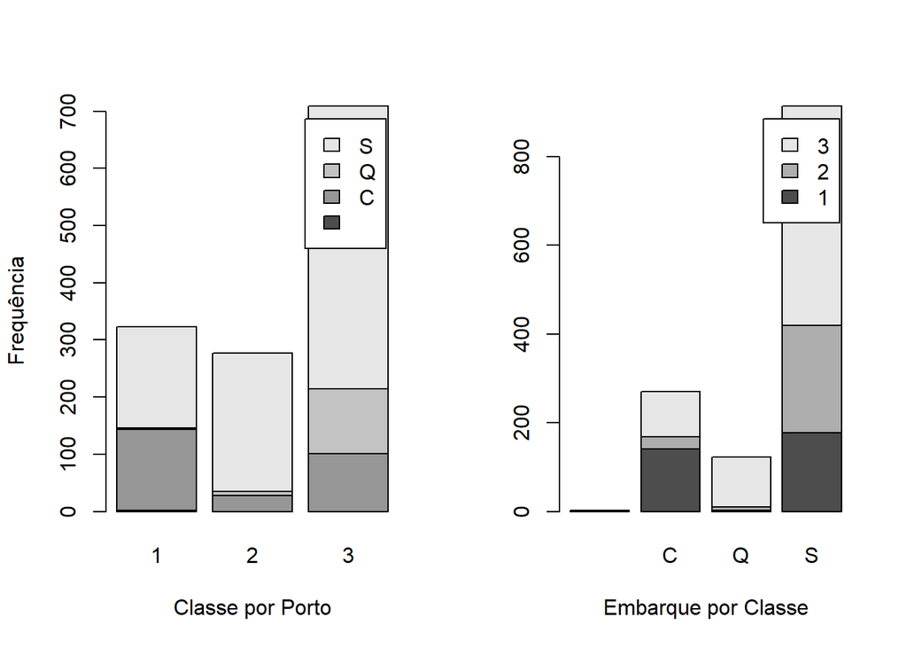

```r
layout(matrix(c(1,2),ncol=2))
barplot(table(df$embarked,df$pclass), xlab="Classe por Porto", ylab="Frequência",
        legend.text = TRUE, beside=FALSE)

barplot(table(df$pclass, df$embarked), xlab="Embarque por Classe", ylab="",
        legend.text = TRUE, beside=FALSE)
```

Pela apreciação desses gráficos, percebe-se que os que embarcaram no porto C foram para as três classes, embora haja predominância na primeira. Além disso, vemos que os que embarcaram no porto S também se espalharam pelas três classes. Quanto aos que embarcaram no porto Q, esses foram basicamente para a terceira classe. Portanto, essas variáveis não parecem estar fortemente associadas.

```
2.Fare (Valor da Tarifa) vs pclass (Classe da Viagem)
```

Parece lógico que os passageiros que pagaram as maiores tarifas foram para as primeiras classes, do contrário, haveria conflito de informações. Então, precisamos averiguar de que formas elas estão associadas.

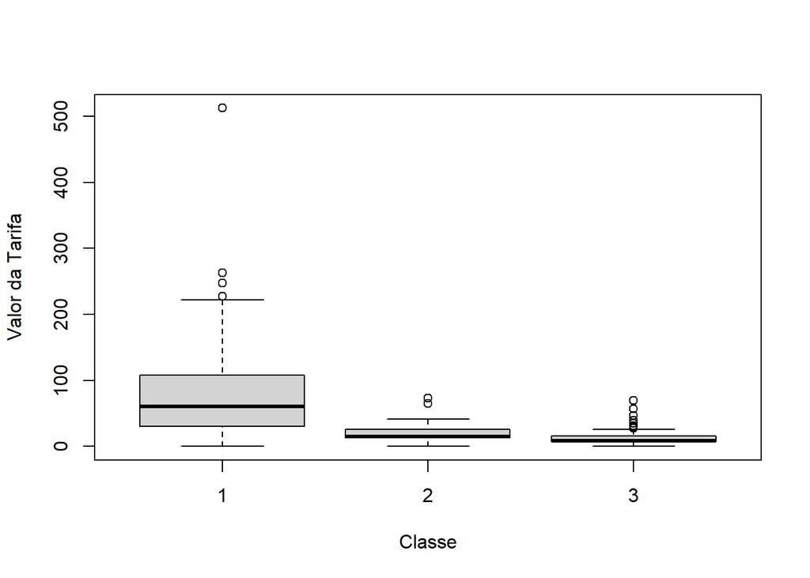

```r
boxplot(df$fare~df$pclass, ylab = "Valor da Tarifa", xlab="Classe",main="")
```

Verifica-se que, em geral, os que **pagaram mais** estão na **primeira classe**, mas há considerável confusão entre as classes quando os valores das tarifas são baixos.

Há, inclusive, observações que são incoerentes. Por exemplo: por que 8 passageiros da terceira classe pagaram quase 60 valores, sendo que mais de 50 passageiros pagaram menos da metade e foram para a primeira classe? Como não há como verificar se os valores estão incorretos e considerando que são poucas observações, podemos excluir da base essas observações ou simplesmente ignorarmos essas aparentes incoerências.

```
3. Variáveis quantitativas
```

As variáveis quantitativas podem ser analisadas em termos de covariâncias e correlações lineares, inclusive as variáveis **sibsp** e **parch** que, embora discretas, possuem poucos valores diferentes. Iremos apresentar a matriz de correlações entre as variáveis.

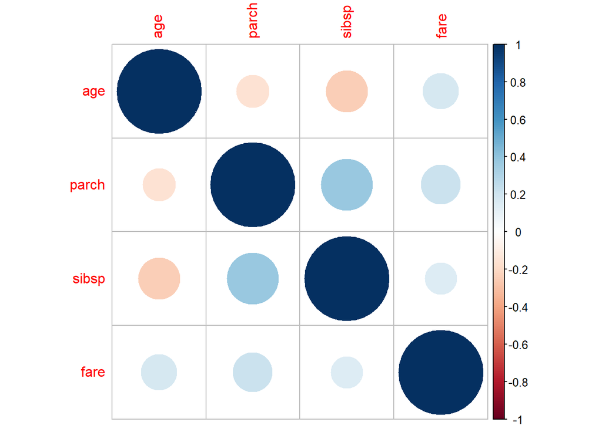

```r
quant<-data.frame(subset(df, select = c(age, parch, sibsp,fare)))
quant<-quant[complete.cases(quant),]
quant.cor<-cor(quant)
#Para a visualização:
library(corrplot)
corrplot(quant.cor)
```

Vemos, portanto, que as correlações lineares entre as variáveis são baixas. Porém, como nem sempre a associação é linear, vamos analisar os gráficos de dispersão:

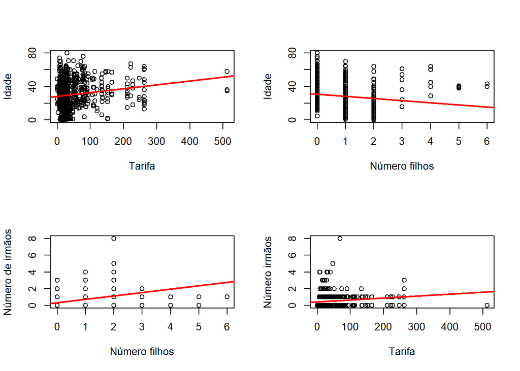

```r
layout(matrix(c(1,2,3,4),ncol=2))
plot(quant$age~quant$fare, xlab="Tarifa", ylab="Idade", main="")
abline(lm(quant$age~quant$fare), col="red", lty=1, lwd=2)
plot(quant$sibsp~quant$parch, xlab="Número filhos", ylab="Número de irmãos", main="")
abline(lm(quant$sibsp~quant$parch), col="red", lty=1, lwd=2)
plot(quant$age~quant$parch, xlab="Número filhos", ylab="Idade", main="")
abline(lm(quant$age~quant$parch), col="red", lty=1, lwd=2)
plot(quant$sibsp~quant$fare, xlab="Tarifa", ylab="Número irmãos", main="")
abline(lm(quant$sibsp~quant$fare), col="red", lty=1, lwd=2)
```

Diante do exposto, percebemos que não há forte associação entre as variáveis explicativas analisadas nesta e nas outras seções.

Antes de passarmos para o capítulo de Inferência Estatística, vamos construir algumas variáveis (“Feature engineering”, em inglês) e propor alguns agrupamentos que poderão ser utilizados no decorrer deste trabalho, esses também são propósitos da Análise Descritiva.

## Construções de variáveis e sugestões de agrupamentos

```
1. Tamanho da Família
```

Vimos que as variáveis **sibsp** e **parch** parecem ajudar a explicar o comportamento da variável resposta. Contudo, percebemos que a maioria dos seus valores estão próximos de zero. Considerando também que essas variáveis não estão fortemente correlacionadas, propomos nesta seção alguns agrupamentos para **sibsp** e **parch** e a criação de novas variáveis.

```r
calc_sibsp_agg<-function(sibsp=NA){
  if(sibsp<1) return("1.Sem irmãos")
  else if(sibsp<3) return("2.Tem 1 ou 2 irmãos")
  else return("3.Tem 3 ou mais irmãos")
}

df["sibsp_agg"]<-sapply(df$sibsp,FUN=calc_sibsp_agg)

calc_parch_agg<-function(parch=NA){
  if(parch<1) return("1.Sem filhos")
  else if(parch<4) return("2.Tem até 3 filhos")
  else return("3.Tem 4 ou mais filhos")
}

df["parch_agg"]<-sapply(df$parch,FUN=calc_parch_agg)
```

Para obter o tamanho da família, basta somar 1 (o próprio passageiro), **sibsp** e **parch**, da seguinte forma:

```r
df["tamanho_familia"]<-df$sibsp+df$parch+1
```

Então, caso o tamanho da família seja igual a 1, significa que o passageiro embarcou sozinho, ou seja, sem pais, filhos, irmãos ou esposos.

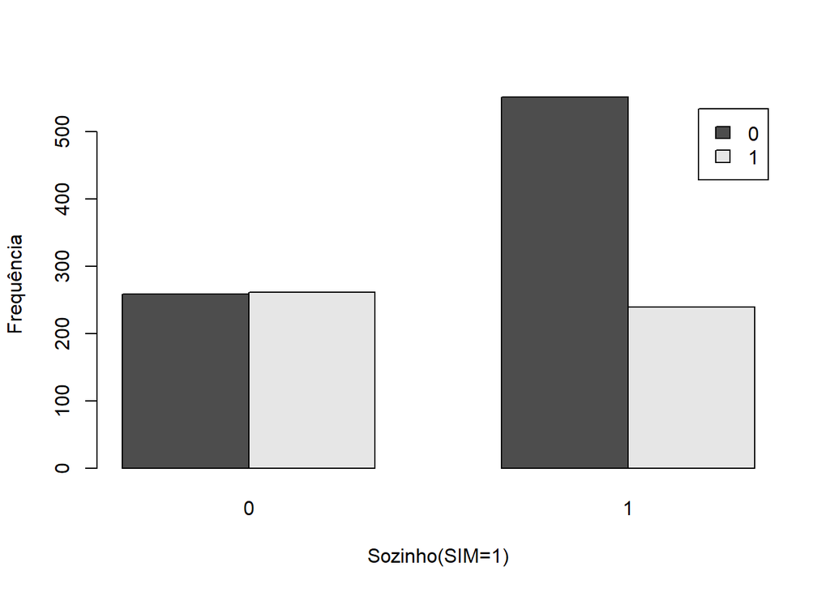

```r
sozinho<-function(fam=1) ifelse(fam==1, 1, 0)

df["sozinho"]<-sapply(df$tamanho_familia,FUN=sozinho)

barplot(table(df$survived,df$sozinho), xlab="Sozinho(SIM=1)", ylab="Frequência",
        legend.text = TRUE, beside=TRUE)
```

Pela observação do gráfico, percebemos que os passageiros que embarcaram sozinho tiveram uma proporção **menor** de sobreviventes. Então podemos considerar a utilização desta variável na modelagem (também podemos testar os outros agrupamentos propostos neste trabalho).

```
2.Idade
```

De acordo com o observado na Análise Descritiva, parece razoável agrupar a idade em três conglomerados: 1.Crianças e jovens; 2.Adultos; 3.Sem idade informada. Para essa nova variável (faixa_etaria) considere o seguinte código:

```r
calc_faixa_etaria<-function(idade=NA){
  if(is.na(idade)){
    faixa_etaria = "3.Sem idade"
    return(faixa_etaria)
  }else if(idade<=15){
    faixa_etaria = "1.Crianças e jovens"
    return(faixa_etaria)
  } else{
    faixa_etaria = "2.Adultos"
    return(faixa_etaria)
  }
}

df["faixa_etaria"]<-sapply(df$age,FUN=calc_faixa_etaria)
```

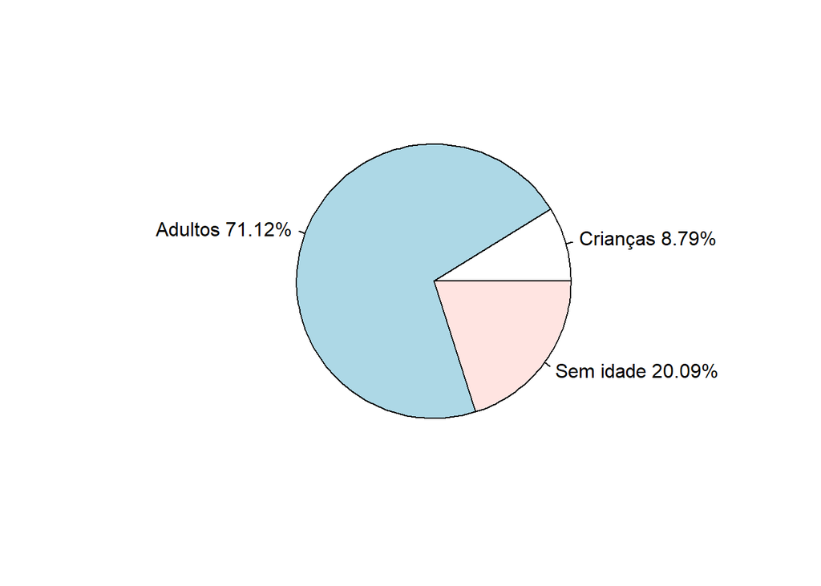

```r
label.pie<-c("Crianças","Adultos", "Sem idade")
freq<-round(table(df$faixa_etaria)/nrow(df)*100,2)
label.pie<-paste(label.pie,freq)
label.pie<-paste(label.pie,"%",sep="")

pie(x=table(df$faixa_etaria), labels=label.pie)
```

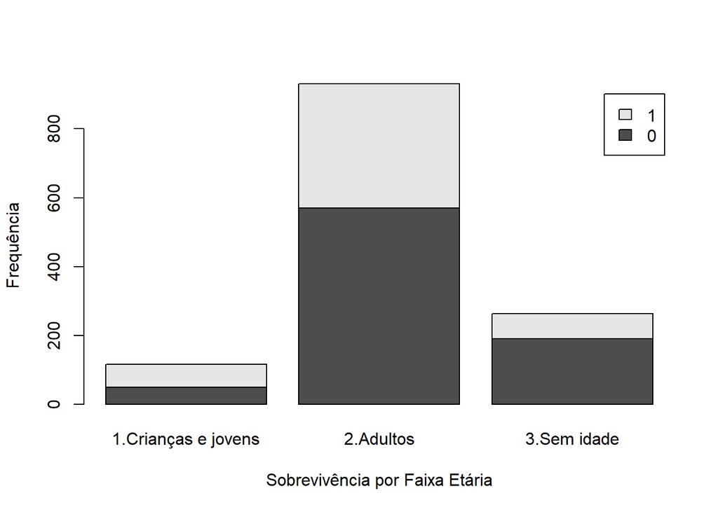

```r
barplot(table(df$survived,df$faixa_etaria), xlab="Sobrevivência por Faixa Etária", ylab="Frequência",
        legend.text = TRUE, beside=FALSE)
```

Como dito, as **crianças** possuem uma **maior** proporção de sobreviventes, seguido dos adultos que sabemos a idade e com a **menor** proporção de sobreviventes estão os passageiros sem idade informada.

Vale dizer, ainda, que às vezes poderemos obter um agrupamento ainda melhor por meio de outras técnicas, por exemplo, através de um modelo de Árvores de Decisão.

Outra forma de trabalharmos com os valores faltantes da idade é preenchendo-os com alguma medida de centralidade.

```r
df["age_2"] = df$age
df$age_2[is.na(df$age_2)]<-mean(df$age_2,na.rm = TRUE)
```

```
3.Valor da Tarifa
```

Observando os gráficos e a tabela resumo (summary) da variável **fare**, vimos que há apenas 1 valor faltante e que há alguns outliers que distorcem a escala e, inclusive, podem comprometer a qualidade do modelo. Com efeito, 75% dos valores (do mínimo até o 3° quartil) são inferiores a 32, enquanto há valores que ultrapassam 512!

Vale adiantar, uma das técnicas do KNN é normalizar as variáveis para que todas exerçam a mesma influência no cálculo das distâncias. Porém, mesmo esta técnica é ineficaz com outliers. Para ilustrarmos nossa assertiva, considere o seguinte exemplo:

Suponha que temos 3 variáveis explicativas: “a”= [1,1,1,2,2,2,3,3,3,4,4,4,5,5,5], “b”= [10000,10000,10000,20000,20000, 20000,30000,30000,30000,40000,40000,40000,50000,50000, 50000] “c” = [1,1,1,2,2,2,3,3,3,4,4,4,5,5,500] Sem a normalização, qualquer variação de “a” ou “c” será irrelevante se comparadas com uma variação “b”. Normalização de uma variável “x”= (obs(x)-min(x))/(max(x)-min(x))

“a_norm” = [0,0,0,0.25,0.25,0.25,0.50,0.50,0.50,0.75,0.75,0.75,1,1,1] “b_norm” = [0,0,0,0.25,0.25,0.25,0.50,0.50,0.50,0.75,0.75,0.75,1,1,1] = “a_norm” “c_norm” = [0,0,0.002,0.002,0.002,0.004,0.004,0.004,0.006,0.006,0.006,0.008, 0.008, 1]

Ou seja, mesmo após a normalização, as variações de “c” continuarão irrelevantes se comparadas às das outras variáveis, pois apenas um outlier conseguiu deixar os outros valores de “c” muito próximos a 0.

Então, para contornar esse problema, podemos:

- 1. categorizar a variável, por exemplo, construindo uma variável chamada **“fare_agg”**;
- 2. agrupar apenas os valores extremos, por exemplo, deixar igual a 100 todos os valores iguais ou superiores a 100;
- 3. excluir da modelagem os valores extremos.

Para o procedimento 1, faremos utilizando técnicas de Árvores de Decisão. Para o 2, iremos construir uma variável **fare_2**. No tocante ao procedimento 3, poderemos testar isso nas modelagens.

## Inferência Estatística.

Nesta seção, apresentaremos uma estimativa pontual e um intervalo de confiança para a proporção de passageiros sobreviventes ao acidente. Além disso, durante a Análise Descritiva, percebemos que algumas variáveis parecem ajudar a explicar o comportamento da variável resposta. Portanto, verificaremos se as diferenças acima encontradas são significativas (ou não) usando técnicas inferenciais.

```
1. Estimação Pontual e Intervalar para a proporção de passageiros sobreviventes.
```

Seja Y uma variável aleatória que representa a sobrevivência de um passageiro, Y pode assumir 2 valores: 1 (sucesso) se o passageiro sobreviveu ao acidente e 0 (fracasso) em caso contrário. Neste caso, estaríamos interessados em descobrir qual é a proporção de sucessos(p). Então Y ~ Bernoulli(p), sendo p o valor do parâmetro que queremos obter.

Assim, supondo que uma sucessão (Yn) seja independente e identicamente distribuída, temos que a soma S = Y1 + Y2 + … Yn tem uma distribuição Binomial (S ~ Bin(n,p)). Além disso, considerando que n é grande, podemos usar o TLC (Teorema do Limite Central) e aproximar a distribuição da soma S por uma distribuição Normal com média np e variância np(1-p).

Deste modo, como nossa amostra y = (y1, y2, …., y1309) é uma realização particular de Y = (Y1, Y2, …., Y1309), o p que queremos encontrar pode ser estimado da seguinte forma: p_est = S/n ~ N(p,p(1-p)/n), em que S = quantidade total de sobreviventes na amostra (soma das Yn) e n é o tamanho da amostra.

```r
p_est<- table(df$survived)[2]/nrow(df)
sd <- sqrt(p_est*(1-p_est)/nrow(df))
LI <- p_est - qnorm(0.975)*sd
LS <- p_est + qnorm(0.975)*sd

#Forma utilizando funções do R: binom.test
binom.test(table(df$survived)[2],nrow(df))
```

```
##
##  Exact binomial test
##
## data:  table(df$survived)[2] and nrow(df)
## number of successes = 500, number of trials = 1309, p-value < 2.2e-16
## alternative hypothesis: true probability of success is not equal to 0.5
## 95 percent confidence interval:
##  0.3555583 0.4089149
## sample estimates:
## probability of success
##               0.381971
```

```r
#Diferença bem pequena. Aqui é usada a distribuição Binomial, enquanto que o intervalo acima foi obtido pela normal
```

Logo, p_est = 500/1309 aprox.= 0,382 (Estimativa Pontual). Adotando o grau de confiança de 95%, temos o intervalo de confiança IC = [LI;LS] = [0,356 ; 0,408].

De acordo com o site da Wikipédia, a embarcação possuiu 2224 pessoas (passageiros e tripulantes) e o número total de mortes estimado está entre 1490 e 1635, ou seja, a proporção de sobreviventes estaria entre [0,265 ; 0,330]. Percebe-se, assim, que a interseção dos intervalos é vazia.

Diante do exposto, podemos formular e testar as seguintes hipóteses: H0: a proporção de sobreviventes é de 0,33 (máximo do intervalo da Wikipédia) vs H1: a proporção de sobreviventes é superior a 0,33. Este teste é unilateral à direita (H0: p = 0,33 vs H1: p > 0,33). Vale dizer, poderíamos fazer um teste bilateral (H0: p = 0,33 vs H1: p != 0,33), mas neste caso poderia ser respondido pelo próprio intervalo de confiança que construímos e, assim, rejeitaríamos H0 ao nível de significância de 5%.

```r
prop.test(x=500,n=1309,p=0.33,alternative = "greater",conf.level = 0.95)
```

```
##
##  1-sample proportions test with continuity correction
##
## data:  500 out of 1309, null probability 0.33
## X-squared = 15.757, df = 1, p-value = 3.602e-05
## alternative hypothesis: true p is greater than 0.33
## 95 percent confidence interval:
##  0.3597698 1.0000000
## sample estimates:
##        p
## 0.381971
```

Portanto, considerando um nível de significância de 5%, rejeitamos H0, ou seja, há evidências significativas que a proporção de sobreviventes é superior a 0.33.

Cabe ressaltar, porém, que os valores apresentados no site não se referem apenas aos passageiros, mas também aos tripulantes. Então, pode ser que a proporção de sobreviventes dos tripulantes foi menor, o que diminuiu a proporção de sobreviventes total. Outra possibilidade é que os poucos passageiros que não fizeram parte da amostra também fizeram com que a proporção de sobreviventes real diminuísse.

```
2. Verificação das diferenças nas proporções de sobreviventes nas variáveis explicativas.

2.1 Sexo (sex)
```

Vimos que as mulheres pareciam ter uma proporção de sobreviventes superior à dos homens. Para verificar nossa assertiva, podemos fazer um teste de hipóteses, em que H0: p_mulheres = p_homens vs H1: p_mulheres != p_homens. Outra forma de verificar isso seria construir um intervalo de confiança para a diferença das proporções e se esse intervalo contiver o valor zero, significaria que não poderíamos rejeitar H0, ou seja, não teríamos evidência de que a diferença das proporções é significativa. Utilizaremos neste (e em todos os outros) um nível de significância de 5% (teste de hipóteses) e 95% de confiança (intervalos de confiança).

```r
p_xx<-table(df$survived,df$sex)[2,1]/table(df$sex)[1]
p_xy<-table(df$survived,df$sex)[2,2]/table(df$sex)[2]

se <- sqrt(p_xx*(1-p_xx)/table(df$sex)[1] + p_xy*(1-p_xy)/table(df$sex)[2])
p_xx-p_xy+c(-1,1)*qnorm(0.975)*se
```

```
## [1] 0.4881260 0.5848405
```

```r
#Outra forma (utilizando uma função do R):
#prop.test
prop.test(x=c(table(df$survived,df$sex)[2,1],table(df$survived,df$sex)[2,2]),n=c(table(df$sex)[1],table(df$sex)[2]))
```

```
##
##  2-sample test for equality of proportions with continuity correction
##
## data:  c(table(df$survived, df$sex)[2, 1], table(df$survived, df$sex)[2, 2]) out of c(table(df$sex)[1], table(df$sex)[2])
## X-squared = 363.62, df = 1, p-value < 2.2e-16
## alternative hypothesis: two.sided
## 95 percent confidence interval:
##  0.4864599 0.5865065
## sample estimates:
##    prop 1    prop 2
## 0.7274678 0.1909846
```

```r
#Podemos testar, também, se p_xx é maior que p_xy
prop.test(x=c(table(df$survived,df$sex)[2,1],table(df$survived,df$sex)[2,2]),n=c(table(df$sex)[1],table(df$sex)[2]), alternative = "greater")
```

```
##
##  2-sample test for equality of proportions with continuity correction
##
## data:  c(table(df$survived, df$sex)[2, 1], table(df$survived, df$sex)[2, 2]) out of c(table(df$sex)[1], table(df$sex)[2])
## X-squared = 363.62, df = 1, p-value < 2.2e-16
## alternative hypothesis: greater
## 95 percent confidence interval:
##  0.4942345 1.0000000
## sample estimates:
##    prop 1    prop 2
## 0.7274678 0.1909846
```

Obtemos, portanto, o intervalo de confiança (0,4881 ; 0,5848). Como não contém o valor zero, rejeitamos a hipótese nula (proporções de sobreviventes iguais). Pela hipótese alternativa, concluímos que a proporção de sobreviventes das mulheres é **maior** que a dos homens.

```
2.2 Classe que Embarcou (pclass)
```

Também percebemos que as pessoas que viajaram na primeira classe tiveram uma proporção **maior** de sobreviventes ( **61,92%** contra **25,53%** dos que viajaram na terceira classe). Podemos fazer o teste: H0: p1=p2=p3 vs H1: há alguma diferença entre as proporções. Porém, é mais interessante fazer dois testes: primeiro verificar se p1=p2 (alternativa p1>p2) e depois verificar se p2=p3(alternativa p2>p3).

```r
#H1: p_1 é maior que p_2?
prop.test(x=c(table(df$survived,df$pclass)[2,1],table(df$survived,df$pclass)[2,2]),n=c(table(df$pclass)[1],table(df$pclass)[2]), alternative = "greater")
```

```
##
##  2-sample test for equality of proportions with continuity correction
##
## data:  c(table(df$survived, df$pclass)[2, 1], table(df$survived, df$pclass)[2, 2]) out of c(table(df$pclass)[1], table(df$pclass)[2])
## X-squared = 20.772, df = 1, p-value = 2.587e-06
## alternative hypothesis: greater
## 95 percent confidence interval:
##  0.1201446 1.0000000
## sample estimates:
##    prop 1    prop 2
## 0.6191950 0.4296029
```

Portanto, ao nível de significância de 5%, rejeita-se H0, ou seja, rejeitamos que as proporções de sobreviventes nas classes 1 e 2 sejam iguais.

```r
#H1: p_2 é maior que p_3?
prop.test(x=c(table(df$survived,df$pclass)[2,2],table(df$survived,df$pclass)[2,3]),n=c(table(df$pclass)[2],table(df$pclass)[3]), alternative = "greater")
```

```
##
##  2-sample test for equality of proportions with continuity correction
##
## data:  c(table(df$survived, df$pclass)[2, 2], table(df$survived, df$pclass)[2, 3]) out of c(table(df$pclass)[2], table(df$pclass)[3])
## X-squared = 27.773, df = 1, p-value = 6.821e-08
## alternative hypothesis: greater
## 95 percent confidence interval:
##  0.1159563 1.0000000
## sample estimates:
##    prop 1    prop 2
## 0.4296029 0.2552891
```

Portanto, ao nível de significância de 5%, rejeita-se H0, ou seja, rejeitamos que as proporções de sobreviventes nas classes 2 e 3 sejam iguais.

```
2.3 Porto em que Embarcou (embarked)
```

Pessoas que embarcaram no porto “C” (Cherbourg) também possuíram uma proporção **maior** de sobreviventes (**55,56%** contra **33,56%** nos outros portos). Vale dizer, o tamanho expressivo da amostra facilita a rejeição de H0 (observe os valores-p dos outros testes, quase todos foram praticamente zero). Aqui, porém, pode ser que não rejeitemos que as proporções dos portos “Q” e “S” sejam iguais.

```r
#H1: p_Q é igual a p_S? - Teste bilateral
prop.test(x=c(table(df$survived,df$embarked)[2,3],table(df$survived,df$embarked)[2,4]),n=c(table(df$embarked)[3],table(df$embarked)[4]), alternative = "two.sided")
```

```
##
##  2-sample test for equality of proportions with continuity correction
##
## data:  c(table(df$survived, df$embarked)[2, 3], table(df$survived, df$embarked)[2, 4]) out of c(table(df$embarked)[3], table(df$embarked)[4])
## X-squared = 0.20448, df = 1, p-value = 0.6511
## alternative hypothesis: two.sided
## 95 percent confidence interval:
##  -0.06954019  0.11977946
## sample estimates:
##    prop 1    prop 2
## 0.3577236 0.3326039
```

Portanto, **não** rejeitamos H0 ao nível de significância de 5%, ou seja, não descartamos a hipótese de que as proporções dos Portos “Q” e “S” são iguais. Como desencargo de consciência, vamos testar se a proporção de sobreviventes no porto C é maior que a de Q.

```r
#H1: p_C é superior a p_Q? - Teste unilateral
prop.test(x=c(table(df$survived,df$embarked)[2,2],table(df$survived,df$embarked)[2,3]),n=c(table(df$embarked)[2],table(df$embarked)[3]), alternative = "greater")
```

```
##
##  2-sample test for equality of proportions with continuity correction
##
## data:  c(table(df$survived, df$embarked)[2, 2], table(df$survived, df$embarked)[2, 3]) out of c(table(df$embarked)[2], table(df$embarked)[3])
## X-squared = 12.452, df = 1, p-value = 0.0002088
## alternative hypothesis: greater
## 95 percent confidence interval:
##  0.1051509 1.0000000
## sample estimates:
##    prop 1    prop 2
## 0.5555556 0.3577236
```

```
2.4 Idade (age)
```

Através da idade, percebemos que as **crianças e jovens** tiveram uma proporção **maior** de sobreviventes. Além disso, dividimos os passageiros em três grupos: **“1.Crianças e jovens**; **2.Adultos** e **3.Sem idade**. Para essa nova variável (faixa_etaria) considere os seguintes testes:

```r
#H1: p_Crianças é superior a p_Adultos? - Teste unilateral
prop.test(x=c(table(df$survived,df$faixa_etaria)[2,1],table(df$survived,df$faixa_etaria)[2,2]),n=c(table(df$faixa_etaria)[1],table(df$faixa_etaria)[2]), alternative = "greater")
```

```
##
##  2-sample test for equality of proportions with continuity correction
##
## data:  c(table(df$survived, df$faixa_etaria)[2, 1], table(df$survived, df$faixa_etaria)[2, 2]) out of c(table(df$faixa_etaria)[1], table(df$faixa_etaria)[2])
## X-squared = 13.923, df = 1, p-value = 9.524e-05
## alternative hypothesis: greater
## 95 percent confidence interval:
##  0.1010048 1.0000000
## sample estimates:
##    prop 1    prop 2
## 0.5739130 0.3877551
```

Portanto, rejeitamos H0 ao nível de significância de 5%, ou seja, a proporção de sobreviventes das crianças é diferente (e maior) que a dos adultos com idade informada. Para testar se proporções de sobreviventes dos adultos é igual a dos passageiros sem idade informada, verifique o seguinte teste:

```r
#H1: p_Adultos_idade é superior a p_sem_idade? - Teste unilateral
prop.test(x=c(table(df$survived,df$faixa_etaria)[2,2],table(df$survived,df$faixa_etaria)[2,3]),n=c(table(df$faixa_etaria)[2],table(df$faixa_etaria)[3]), alternative = "greater")
```

```
##
##  2-sample test for equality of proportions with continuity correction
##
## data:  c(table(df$survived, df$faixa_etaria)[2, 2], table(df$survived, df$faixa_etaria)[2, 3]) out of c(table(df$faixa_etaria)[2], table(df$faixa_etaria)[3])
## X-squared = 10.291, df = 1, p-value = 0.0006685
## alternative hypothesis: greater
## 95 percent confidence interval:
##  0.05528386 1.00000000
## sample estimates:
##    prop 1    prop 2
## 0.3877551 0.2775665
```

Os outros testes podem ser feitos de forma semelhante à que apresentamos aqui. Então, para não ficar repetitivo, deixemos a cargo do leitor.

## Modelagem.

Como vimos, a variável resposta é dicotômica e os modelos mais adequados para sua previsão são os de classificação supervisionados.

Primeiro iremos apresentar 3 modelos: **Árvore de Decisão (Simples)**, **Regressão Logística** e o **KNN**. Depois, vamos tentar aumentar a acurácia da previsão, refinando os modelos com algumas técnicas. Para evitarmos o chamado **overfitting**, vamos construir os modelos utilizando uma parte da amostra e com outra parte vamos validar os resultados. Geralmente, é utilizado 70% da amostra para modelagem (ou treinamento) e os outros 30% são destinados à validação.

```
1. Pré-processamento
```

Antes de construirmos os modelos, precisamos fazer alguns pré-processamentos, como criar labels para as variáveis categóricas, tratar os valores faltantes e dividir a amostra em treino e teste (já mencionado). Quando aplicar o KNN, precisamos de pré-processamentos adicionais, mas para não ficar confusas as bases, faremos as devidas alterações na seção do KNN.

```r
#Categorizando as variáveis criadas
df$faixa_etaria<-factor(df$faixa_etaria)
df$sozinho<-factor(df$sozinho)
df$sibsp_agg<-factor(df$sibsp_agg)
df$parch_agg<-factor(df$parch_agg)

#Tratando os valores faltantes
#Temos apenas 1 obs na fare e 2 na embarked. Idade já resolvida com age_2 e/ou faixa_etaria
df$fare[is.na(df$fare)]<-mean(df$fare,na.rm = TRUE)
df$embarked[df$embarked==""]<-"S" #classe mais frequente
df$embarked<-factor(df$embarked) #necessária a refactorização, pois o vazio "" virou uma categoria.
```

Para fazer a divisão em treino e teste, poderíamos usar um pacote (por exemplo, “caTools”). Porém, em vez de instalarmos um pacote, podemos simplesmente gerar números aleatórios, conforme se verifica abaixo:

```r
set.seed(17) #Para manter a mesma sequência pseudo-aleatória
sample<-sort(sample(nrow(df),nrow(df)*0.7))
train<-df[sample,]
val<-df[-sample,]
```

```
2. Árvore de Decisão Simples
```

O modelo de Árvore de Decisão é de fácil interpretação e lida muito bem com diversos tipos de variáveis (a variável resposta, por exemplo, pode ser qualitativa ou quantitativa), também lida bem com valores faltantes e não requer pré-processamentos (embora manteremos os feitos na seção anterior).

Além disso, ele pode ser usado como ponto de partida para outros modelos, por isso será apresentado primeiro. Vale dizer, ainda, que podemos aplicar a técnica de Random Forest e melhorar ainda mais a performance do modelo, pese o fato de ficar um pouco menos interpretativo.

O ponto negativo da Árvore de Decisão é não conseguirmos controlar bem o número de folhas produzidas. Até podemos especificar quantos entroncamentos queremos, mas às vezes com tamanho “n” o modelo fica “underfit” e com “n+1” já fica “overfit”. Para exemplificar nossa assertiva, é possível construir uma árvore que dê acurácia de 100% para a base de treinamento, mas obviamente nesses casos o modelo costuma ir muito mal na base de validação (e, consequentemente, nas futuras previsões que tenhamos que fazer na prática).

Para construir um modelo de Árvore de Decisão, precisamos importar as bibliotecas rpart e rpart.plot. Após isto, já construiremos uma árvore.

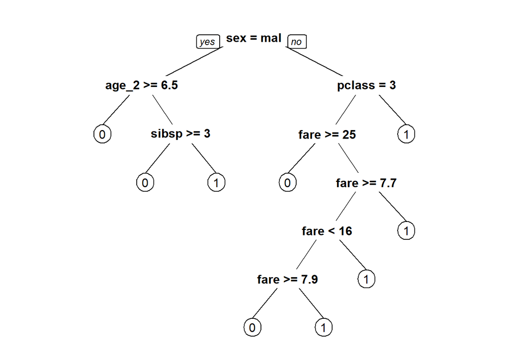

```r
library(rpart)
library(rpart.plot)
tree<-rpart(survived ~., data=train)
prp(tree)
```

Basta olharmos a figura acima que rapidamente entendemos quais variáveis foram utilizadas na construção do modelo e sua importância. A primeira foi **sex**, sendo auxiliada pelas variáveis **age_2** (o algoritmo preferiu nossa transformação na variável **age** original) e **pclass**, a qual foi auxiliada pela variável **fare**. Ao percorrermos um caminho da árvore, percebemos qual foi a previsão do modelo para um passageiro com as características do caminho. Por exemplo, homens com menos de 6,5 anos e que possuíam menos de 3 irmãos foram classificados como sobreviventes.

Aplicando este modelo na base de validação, obtemos os seguintes resultados:

```r
pred_tree<-predict(tree, val, type="class")
acc<-sum(table(pred_tree,val$survived)[1,1],table(pred_tree,val$survived)[2,2])/length(pred_tree)
print(acc)
```

```
## [1] 0.7811705
```

Temos, portanto, uma acurácia de **78,12%**. Quanto à matriz de confusão, observe a seguinte matriz:

```r
table(pred_tree,real=val$survived)
```

```
##          real
## pred_tree   0   1
##         0 212  62
##         1  24  95
```

Além da acurácia total, temos a acurácia de **89,83%** (212/236) para os que faleceram e a de **60,51%** (95/157) para os sobreviventes, ou seja, o modelo é pior para classificar os sobreviventes.

Como prometido, vamos agrupar a variável **fare** utilizando uma Árvore de Decisão. Este agrupamento poderá ser utilizado nos próximos modelos. Como estamos apenas obtendo um agrupamento para uma variável, não tem problema usarmos toda a amostra.

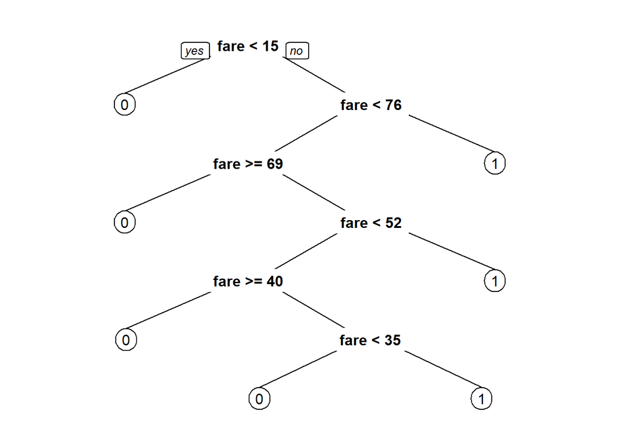

```r
fare_agg<-rpart(survived ~fare, data=df)
prp(fare_agg)
```

Pelo desenho, vemos os seguintes pontos de cortes:

```r
calc_fare_agg<-function(fare=NA){
  if(fare<15) return("1.Fare_1")
  else if(fare<35) return("2.Fare_2")
  else if(fare<52) return("3.Fare_3")
  else if(fare<76) return("4.Fare_4")
  else return("5.Fare_5")
}
df["fare_agg"]<-sapply(df$fare,FUN=calc_fare_agg)
df$fare_agg<-factor(df$fare_agg)
```

Vamos fazer gráficos para ver se este agrupamento faz sentido. Então, considere:

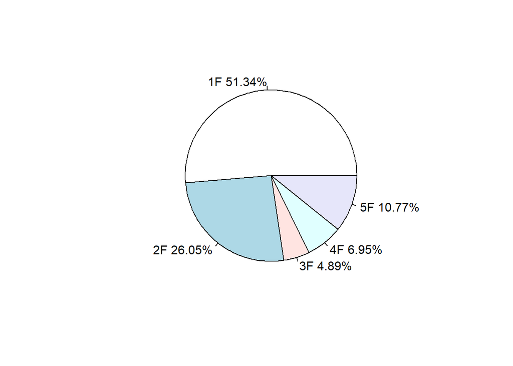

```r
label.pie<-c("1F","2F", "3F", "4F", "5F")
freq<-round(table(df$fare_agg)/nrow(df)*100,2)
label.pie<-paste(label.pie,freq)
label.pie<-paste(label.pie,"%",sep="")
pie(x=table(df$fare_agg), labels=label.pie)
```

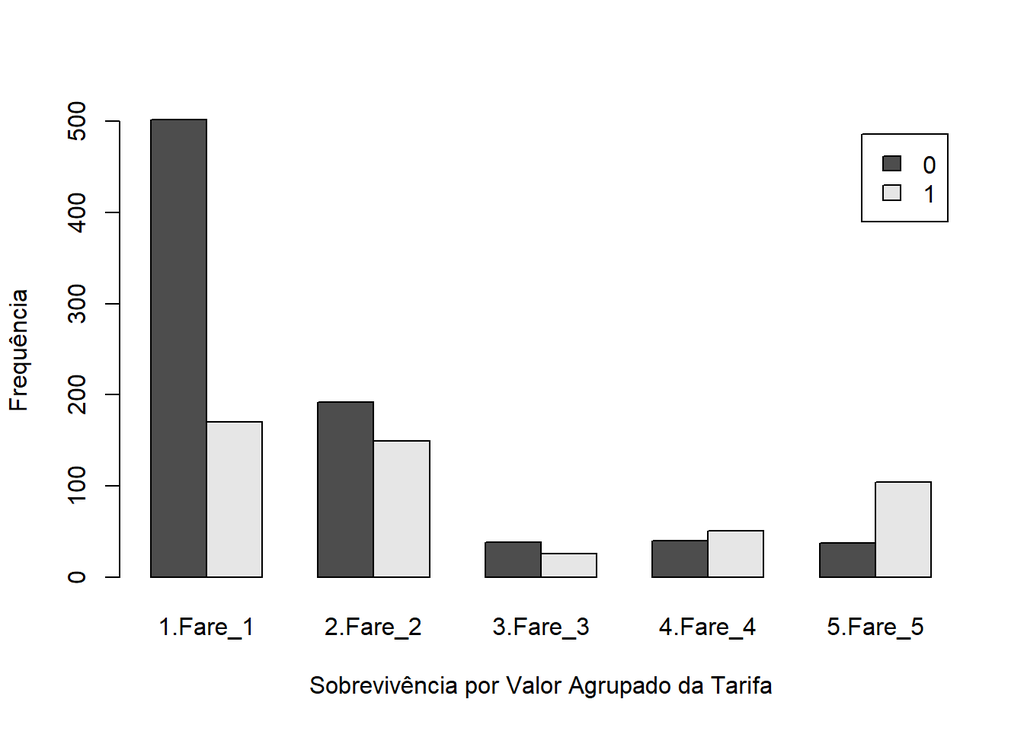

```r
barplot(table(df$survived,df$fare_agg), xlab="Sobrevivência por Valor Agrupado da Tarifa", ylab="Frequência",
        legend.text = TRUE, beside=TRUE)
```

Portanto, este agrupamento tem representatividade nas categorias e ainda manteve o verificado na Análise Descritiva, pois os passageiros nos grupos que pagaram mais tiveram maior proporção de sobreviventes. Além disso, vamos usar o valor 76 como sendo o máximo permitido para a variável **fare_2**.

```r
max_fare<-function(fare=0) ifelse(fare<76, fare, 76)
df["fare_2"]<-sapply(df$fare,FUN=max_fare)
```

```
3. Regressão Logística
```

Para construirmos um modelo de regressão logística, podemos utilizar a função glm. Para a primeira versão do modelo, utilizaremos as variáveis originais, exceto pela **age**, pois não podemos ter valores faltantes na Regressão Logística.

```r
df_reg<-subset(df, select=-c(fare_2, age, fare_agg, sozinho, tamanho_familia,
                     sibsp_agg, parch_agg, faixa_etaria))
train<-df_reg[sample,]
val<-df_reg[-sample,]
m1<-glm(formula = survived ~ ., data = train, family="binomial")
summary(m1)
```

```
##
## Call:
## glm(formula = survived ~ ., family = "binomial", data = train)
##
## Deviance Residuals:
##     Min       1Q   Median       3Q      Max
## -2.4854  -0.6412  -0.4710   0.6422   2.3810
##
## Coefficients:
##              Estimate Std. Error z value Pr(>|z|)
## (Intercept)  3.538540   0.443580   7.977 1.50e-15 ***
## pclass2     -0.843816   0.288521  -2.925 0.003449 **
## pclass3     -1.658079   0.280827  -5.904 3.54e-09 ***
## sexmale     -2.570503   0.189585 -13.559  < 2e-16 ***
## sibsp       -0.448230   0.115278  -3.888 0.000101 ***
## parch        0.051228   0.120007   0.427 0.669468
## fare         0.002820   0.002197   1.284 0.199286
## embarkedQ   -0.476126   0.365857  -1.301 0.193122
## embarkedS   -0.514019   0.221712  -2.318 0.020427 *
## age_2       -0.032079   0.007455  -4.303 1.69e-05 ***
## ---
## Signif. codes:  0 '***' 0.001 '**' 0.01 '*' 0.05 '.' 0.1 ' ' 1
##
## (Dispersion parameter for binomial family taken to be 1)
##
##     Null deviance: 1211.5  on 915  degrees of freedom
## Residual deviance:  837.2  on 906  degrees of freedom
## AIC: 857.2
##
## Number of Fisher Scoring iterations: 5
```

Com o resultado do primeiro modelo, percebemos que as variáveis fare, embarkedQ e parch foram rejeitadas. Considerando que não rejeitamos no capítulo de Inferência que a proporção de quem embarcou no porto Q era igual aos que embarcaram no porto S, faremos essa modificação. Contudo, chamaremos de “embarked_agg” para não danificarmos a variável original.

```r
df["embarked_agg"]<-df$embarked
df$embarked_agg[df$embarked_agg=="Q"]<-"S"
df$embarked_agg<-factor(df$embarked_agg)

df_reg<-subset(df, select=-c(fare_2, age, fare_agg, sozinho, tamanho_familia, sibsp_agg, parch_agg, faixa_etaria))
train<-df_reg[sample,]
val<-df_reg[-sample,]

train<-subset(train, select=-c(fare,parch,embarked))
m2<-glm(formula = survived ~ ., data = train, family="binomial")
summary(m2)
```

```
##
## Call:
## glm(formula = survived ~ ., family = "binomial", data = train)
##
## Deviance Residuals:
##     Min       1Q   Median       3Q      Max
## -2.3951  -0.6427  -0.4673   0.6620   2.3788
##
## Coefficients:
##                Estimate Std. Error z value Pr(>|z|)
## (Intercept)    3.834304   0.398641   9.618  < 2e-16 ***
## pclass2       -0.999713   0.262707  -3.805 0.000142 ***
## pclass3       -1.844807   0.234774  -7.858 3.91e-15 ***
## sexmale       -2.607803   0.185077 -14.090  < 2e-16 ***
## sibsp         -0.402354   0.106195  -3.789 0.000151 ***
## age_2         -0.032629   0.007413  -4.402 1.07e-05 ***
## embarked_aggS -0.557005   0.216383  -2.574 0.010048 *
## ---
## Signif. codes:  0 '***' 0.001 '**' 0.01 '*' 0.05 '.' 0.1 ' ' 1
##
## (Dispersion parameter for binomial family taken to be 1)
##
##     Null deviance: 1211.47  on 915  degrees of freedom
## Residual deviance:  839.56  on 909  degrees of freedom
## AIC: 853.56
##
## Number of Fisher Scoring iterations: 5
```

Como nenhuma variável foi rejeitada (todos os betas são significamente diferentes de zero), veremos agora se os coeficientes estão coerentes com o que seria esperado. Podemos ver, por exemplo, que a medida que piora a classe de embarque, diminui a probabilidade de sobrevivência (coeficientes estão negativos e “punem” cada vez mais). Além disso, vemos que os resíduos estão bem distribuídos e em torno do zero. Quanto ao AIC, obtivemos o valor de 853,56.

Contudo, há um pequeno conflito na variável **sibsp**, pois com 1 ou 2 irmãos, a proporção de sobreviventes é maior que a de 0, mas o sinal do coeficiente é negativo (com 3 ou mais o valor precisava ser negativo mesmo). Porém, provavelmente a variável **sozinho** vai contornar essa conflito, “punindo” quem está com **sibsp** igual a 0.

Antes de tentarmos melhorar a performance do modelo, vamos apresentar a acurácia e a matriz de confusão da base de validação.

```r
res<-predict(m2,val,type="response")
confmatrix<-table(pred=res>0.5, verd=val$survived)
acc<-(confmatrix[1,1]+confmatrix[2,2])/sum(confmatrix)
print(acc)
```

```
## [1] 0.7811705
```

```r
confmatrix
```

```
##        verd
## pred      0   1
##   FALSE 199  49
##   TRUE   37 108
```

Portanto temos a acurácia total de **78,12%**, de **84,32%** (199/236) para os que faleceram e de **68,79%** (108/157) para os que sobreviveram.

Cabe observar, ainda, que obtivemos a mesma acurácia que a do modelo de Árvore de Decisão, tendo a vantagem do modelo de Regressão Logística estar mais equilibrado na acurácia dos sobreviventes e dos não sobreviventes.

Fazendo modelos com as novas variáveis, só conseguimos melhora com a variável **sozinho**. Com ela, a acurácia total foi de **78,62%**. Observemos o resultado:

```r
train<-df[sample,]
val<-df[-sample,]
train<-subset(train, select=-c(age,fare,parch,embarked, tamanho_familia,
                               fare_agg,fare_2, faixa_etaria, parch_agg, sibsp_agg))
mf<-glm(formula = survived ~ ., data = train, family="binomial")
summary(mf)
```

```
##
## Call:
## glm(formula = survived ~ ., family = "binomial", data = train)
##
## Deviance Residuals:
##     Min       1Q   Median       3Q      Max
## -2.4761  -0.6388  -0.4536   0.6237   2.3460
##
## Coefficients:
##                Estimate Std. Error z value Pr(>|z|)
## (Intercept)    4.258295   0.434442   9.802  < 2e-16 ***
## pclass2       -1.018413   0.265092  -3.842 0.000122 ***
## pclass3       -1.758748   0.237778  -7.397 1.40e-13 ***
## sexmale       -2.474001   0.187530 -13.193  < 2e-16 ***
## sibsp         -0.721361   0.163316  -4.417 1.00e-05 ***
## sozinho1      -0.813130   0.252463  -3.221 0.001278 **
## age_2         -0.032836   0.007495  -4.381 1.18e-05 ***
## embarked_aggS -0.453435   0.219553  -2.065 0.038898 *
## ---
## Signif. codes:  0 '***' 0.001 '**' 0.01 '*' 0.05 '.' 0.1 ' ' 1
##
## (Dispersion parameter for binomial family taken to be 1)
##
##     Null deviance: 1211.5  on 915  degrees of freedom
## Residual deviance:  828.8  on 908  degrees of freedom
## AIC: 844.8
##
## Number of Fisher Scoring iterations: 5
```

```r
res<-predict(mf,val,type="response")
confmatrix<-table(pred_log=res>0.5, verd=val$survived)
acc<-(confmatrix[1,1]+confmatrix[2,2])/sum(confmatrix)
print(acc)
```

```
## [1] 0.7862595
```

Os resíduos deste modelo continuam bem distribuídos em torno do zero, os coeficientes estão coerentes com o esperado e ainda diminuímos o AIC, então este modelo foi o melhor que conseguimos construir com as variáveis que temos à disposição.

```r
print(confmatrix)
```

```
##         verd
## pred_log   0   1
##    FALSE 198  46
##    TRUE   38 111
```

Percebe-se que o modelo acerta **83,90%** (198/236) dos passageiros que não sobreviveram e acerta **70,70%** (111/157) dos que sobreviveram. Logo, em termos de acurácia e equilíbrio nos acertos de 0 e 1, o modelo de **Regressão Logística é melhor que o de Árvore de Decisão**.

```
4.KNN
```

A ideia do KNN é classificar um novo elemento observando os k elementos mais próximos, sendo k um valor que chamamos de hiperparâmetro do modelo. Não existe uma fórmula para se obter k, geralmente são utilizados números ímpares para evitar empates. Obteremos esse valor treinando o algoritmo iterativamente e verificando qual apresentou a maior acurácia.

Outro problema que o KNN enfrenta é que a variável resposta precisa ser equilibrada, do contrário, fica difícil para a categoria com pouca representatividade “vencer na votação”. No caso em tela, temos que a proporção de sobreviventes é de 0,382, temos, então, um desbalanceamento considerável.

Precisamos que todas as variáveis explicativas sejam numéricas. Então, precisaremos fazer pré-processamentos adicionais. Além disso, assim como na Regressão Logística, vamos trabalhar primeiro com as variáveis originais (novamente não podemos utilizar a **age**).

```r
library(caret)
target<-subset(df, select=survived)
df_knn<-subset(df, select=-c(fare_2, age, sozinho, fare_agg, tamanho_familia, sibsp_agg, parch_agg, faixa_etaria, survived, embarked_agg))
dummy<-dummyVars(" ~. ", data=df_knn)
df_knn<-data.frame(predict(dummy,newdata=df_knn))
```

Explicamos que as variáveis precisam ser normalizadas. Então considere o seguinte código:

```r
normalize<-function(x) return((x-min(x))/(max(x)-min(x)))
#Aplicando a normalização na base:
df_norm<-as.data.frame(lapply(df_knn, normalize))
X_train<-df_norm[sample,] #seed(17) já foi fixado
X_val<-df_norm[-sample,]
y_train<-target[sample,]
y_val<-target[-sample,]
```

Para exemplificarmos o funcionamento do algoritmo, criaremos um com k=3 (poderíamos ter escolhido outro valor).

```r
require(class)
m1<-knn(train = X_train, test = X_val, cl=y_train, k=3)
acc<-sum(table(m1,y_val)[1,1],table(m1,y_val)[2,2])/length(y_val)
print(acc)
```

```
## [1] 0.7913486
```

Portanto, já na primeira tentativa, conseguimos uma acurácia superior às obtidas nos outros modelos. Passemos, agora, a obter um valor melhor de k.

```r
l_acc<-c()#inicializando o vetor de acc
for( i in 1:41){
  m1<-knn(train = X_train, test = X_val, cl=y_train, k=i)
  acc<-sum(table(m1,y_val)[1,1],table(m1,y_val)[2,2])/length(y_val)
  l_acc<-append(l_acc,acc)
}

cat('Para k = ',which.max(l_acc)," temos acc = ",max(l_acc))
```

```
## Para k =  15  temos acc =  0.8015267
```

Portanto, o melhor valor de k para a base de validação é **k=15** com uma acurácia de **80,15%**. O gráfico a seguir mostra o acc de todos os k gerados:

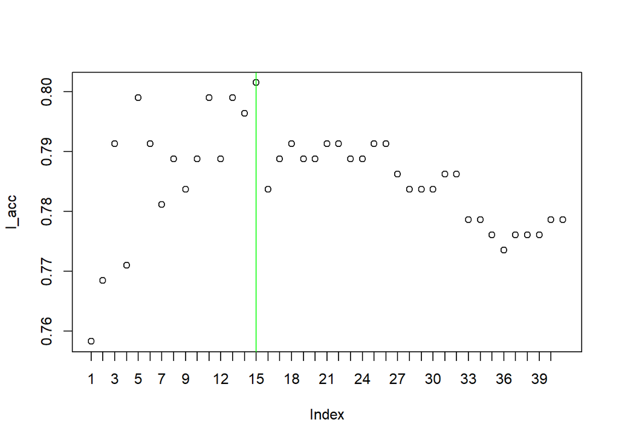

```r
plot(l_acc,xaxt="n")
axis(1,at=1:40)
abline(v=15,col="green")
```

De forma análoga ao que fizemos na regressão logística, vamos verificar se podemos melhorar este modelo.

Ao testar novas combinações, percebemos que com a **fare_2** o modelo ficou melhor que o que usava **fare** (lembrar que outlier pode invalidar uma variável). Então observe o modelo final de KNN:

```r
df_knn<-subset(df, select=-c( age, sozinho, fare_agg, tamanho_familia,parch_agg, sibsp_agg, embarked_agg,
                             survived, fare,faixa_etaria))
dummy<-dummyVars(" ~. ", data=df_knn)
df_knn<-data.frame(predict(dummy,newdata=df_knn))

df_norm<-as.data.frame(lapply(df_knn, normalize))
X_train<-df_norm[sample,]
X_val<-df_norm[-sample,]
y_train<-target[sample,]
y_val<-target[-sample,]

l_acc<-c()#inicializando o vetor de acc
for( i in 1:41){
  m1<-knn(train = X_train, test = X_val, cl=y_train, k=i)
  acc<-sum(table(m1,y_val)[1,1],table(m1,y_val)[2,2])/length(y_val)
  l_acc<-append(l_acc,acc)
}

cat('Para k = ',which.max(l_acc)," temos acc = ",max(l_acc))
```

```
## Para k =  15  temos acc =  0.8117048
```

Com k=15, obtivemos uma acurácia total de **81,17%**, de **92,37%** (218/236) para os que faleceram e de **64,33%** (101/157) para os sobreviventes. Se não, vejamos:

```r
knn_final<-knn(train = X_train, test = X_val, cl=y_train, k=15)
  acc<-sum(table(knn_final,y_val)[1,1],table(knn_final,y_val)[2,2])/length(y_val)
  print(acc)
```

```
## [1] 0.8117048
```

```r
  table(knn_final,y_val)
```

```
##          y_val
## knn_final   0   1
##         0 218  56
##         1  18 101
```

```
5.Escolha do melhor modelo
```

Podemos escolher qual modelo vamos aplicar na vida real com base em diversos critérios como, por exemplo, performance, interpretabilidade, tempo decorrido até a previsão, etc…

Ao invés de escolher o melhor modelo, podemos utilizar todas as previsões e escolher a mais frequente. Por exemplo, suponha que para um determinado passageiro teríamos que o modelo de KNN e o de Regressão Logística classificaram o passageiro como sobrevivente e o de Árvore de Decisão o classificou como não-sobrevivente. Nessa caso, teríamos que a previsão seria igual a 1 (passageiro sobreviveu). Aliás, fizemos 3 modelos no decorrer deste trabalho justamente para mostrarmos esta técnica. Então, considere o seguinte código:

```r
val<-df[-sample,]
val["p_arvore"]<-as.numeric(pred_tree)-1
val["pred_log"]<-ifelse(res>0.5,1,0)
val["p_knn"]<-as.numeric(knn_final)
val["p_voto"]<-ifelse(val$p_arvore+val$pred_log+val$p_knn>1,1,0)
acc_voto<-(table(val$p_voto, val$survived)[1,1]+table(val$p_voto, val$survived)[2,2])/nrow(val)
table(pred=val$p_voto, real=val$survived)
```

```
##     real
## pred   0   1
##    0 196  42
##    1  40 115
```

Percebemos que a acurácia total foi de **79,13%** (311/393), para os que faleceram foi de **83,05%** (196/236) e de **73,25%** (115/157) para os sobreviventes. Portanto, embora a acurácia total seja inferior a de **81,17%** obtida pelo KNN, o modelo de votação ficou mais equilibrado.

Mostramos que para todos os modelos era possível aumentar sua performance, fazendo transformações de algumas variáveis, criando outras variáveis, usando outros tipos de métodos do modelo. Por exemplo, no KNN é usada a distância euclidiana, talvez se usássemos a distância de Manhattan fosse melhor, ou se aplicássemos antes técnicas de componentes principais, “boosting”, “bagging”, etc… Porém, por outro lado, sempre estamos correndo o risco de cometer **overfitting** e, após tanto trabalho, o modelo não funcionaria na prática.

Quanto aos modelos apresentados neste trabalho, vimos que todos tinham vantagens e desvantagens. Se optássemos por praticidade e interpretabilidade, o obtido por Árvores de Decisão seria o mais adequado. Caso déssemos preferência para uma maior acurácia dos sobreviventes, escolheríamos o obtido pela Regressão Logística (ou pelo método de votação). Se quisessemos a maior acurácia, escolheríamos o KNN com k=15.

## Conclusões.

Por meio da base do Titanic, conseguimos aprender ainda mais sobre o acidente histórico que ocorreu há pouco mais de 100 anos. De fato, vimos que o **gênero feminino, as crianças e os que pagaram maiores tarifas, embarcaram no porto C e na primeira classe** tiveram **maior** proporção de sobreviventes.

Também extrapolamos os resultados obtidos na amostra para a população, constituída pelo conjunto de passageiros que embarcaram no Titanic, obtendo o Intervalo de Confiança [0,356 ; 0,408] e a estimativa pontual de **0,382**.

Por fim, apresentamos um modelo de Regressão Logística que apresentou uma acurácia total de **78,62%**, um de Árvore de Decisão que também apresentou uma acurácia de **78,12%** e um modelo de KNN com k=15, que apresentou uma acurácia de **81,17%**, sendo esses valores excelentes, principalmente quando consideramos que a base não apresenta muitas variáveis explicativas.

## Agradecimentos.

Este trabalho foi concebido majoritariamente com os conhecimentos adquiridos nos dois primeiros meses do curso de Mestrado de Estatística para Ciências de Dados da Universidade do Minho.

De fato, para a Análise Descritiva Univariada, muito do conhecimento foi obtido na matéria de Fundamentos e Aplicações de Estatística. No capítulo de Inferência Estatística, todos os testes e códigos do R lá utilizados foram aprendidos na cadeira de mesmo nome. A análise dos “betas” de cada variável foi ensinada na matéria de Modelos Lineares (por analogia aos Beta0 e Beta1 da Regressão Linear). No tocante à modelagem, foi utilizado o conhecimento adquirido no evento chamado “One Day Meeting” patrocinado pela UMinho, que contou ainda com mais técnicas de Machine Learning. Por fim, o mais importante para a confecção deste trabalho foi obtido na cadeira de Estatística Computacional, pois foi aprendido a utilizar o R e o SPSS (este software também é uma ferramenta fundamental para todos que utilizam a Estatística em seus trabalhos e estudos).

Diante do exposto, foi imprescindível a criação de um capítulo exclusivo para o agradecimento à UMinho.

## Referências.

- Fatos históricos sobre o Titanic: (https://en.wikipedia.org/wiki/Titanic)
- Cursos de Python, Data Science e Machine Learning: (https://www.youtube.com/c/DataICMC) - são alunos da Universidade de São Paulo que criaram este canal para compartilhar conhecimento.
- Site com diversos cursos gratuitos, bases de dados e competições de Machine Learning: (https://www.kaggle.com)
- Outros Canais do Youtube onde aprendi comandos sobre modelagem utilizando o R: (https://www.youtube.com/c/rdjalayer) (https://www.youtube.com/c/SimplilearnOfficial)